# Computing transport coefficients using Molly.jl

JuliaCon 2026 (JuliaMolSim minisymposium)

Noé Blassel, joint work with Gabriel Stoltz (École des Ponts)

Mathematics for Materials Modelling, Institute of Mathematics, EPFL

August 13, 2026

## Outline

- **Transport coefficients** - macroscopic transport laws from microscopic simulations
- **Nonequilibrium molecular dynamics (NEMD) & Green–Kubo** in `Molly.jl` - minimal implementations of classical methods
- **Fixing the flux** - a new approach with promising variance reduction properties

## Transport coefficients

- **Thermodynamic equilibrium**: time-symmetric microscopic dynamics & static macroscopic state (no net observable flux)
- **Nonequilibrium steady state (NESS)**: non-reversible dynamics from **non-conservative forces** and **net macroscopic fluxes**
- **Transport coefficients**: constants in **constitutive equations** (heat/Fourier, diffusion/Fick, viscosity/Newton, conductivity/Ohm…)
- **Sensitivities of macroscopic fluxes to external stimuli**

**Quantitative input in macroscopic models** (Navier–Stokes, reaction-diffusion models…)

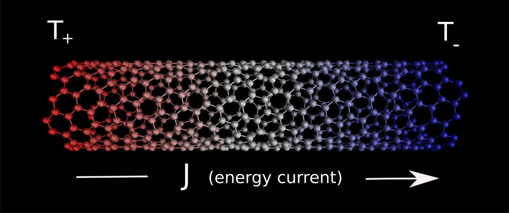

$$\mathcal{J} = -\kappa\,\nabla T \qquad \text{(Fourier's law)}$$

The **energy flux** is proportional to the **temperature gradient**

## Formalization: linear response of stochastic dynamics

**Nonequilibrium dynamics**

$$\mathrm{d}X_t^\eta = \color{blue}{b(X_t^\eta)\,\mathrm{d}t + \sigma(X_t^\eta)\,\mathrm{d}W_t} + \color{red}{\eta\,F(X_t^\eta)\,\mathrm{d}t}$$

**Equilibrium MD** (Langevin, dissipative particle dynamics…) + **nonequilibrium forcing**, of magnitude $\eta$

The state $X^\eta_t\in\mathcal{X}$ (positions and momenta) evolves **stochastically**

The NESS is an **invariant probability measure** $\mu_\eta \in \mathcal{P}(\mathcal{X})$ under $X^\eta$

Equilibrium is characterized by an **explicit steady-state** (Gibbs distribution)
$$\color{blue}{\mu_0(\mathrm{d}x) = \frac1{Z(\beta)}\mathrm{e}^{-\beta E}\,\mathrm{d}x}$$

**Linear response**

Given a **flux observable** $R:\mathcal{X}\to\mathbb{R}$ with $\langle R\rangle_{\eta=0} = 0$, the **macroscopic flux** is
$$\langle R\rangle_\eta = \int_\mathcal{X}R(x)\,\mu_\eta(\mathrm{d}x)$$

The transport coefficient is the **sensitivity of the flux to the forcing**
$$\alpha_{F,R} = \lim_{\eta\to 0}\,\frac1\eta \langle R\rangle_\eta = \int_{\mathcal{X}}R(x)\,\partial_\eta\left.\mu_\eta(\mathrm{d}x)\right|_{\eta=0}$$

Challenge: derivative of a **high-dimensional integral**

**Recent review**<sup>1</sup> of computational approaches and numerical analysis

[^1]: N. Blassel, L. Carillo, S. Darshan, R. Gastaldello, A. Iacobucci, E. Marini, et al., **Mathematical Analysis and Numerical Methods for the Computation of Transport Coefficients in Molecular Dynamics**, *Preprint arXiv:2605.10507*, 2026.

## Two classical methods

**Nonequilibrium molecular dynamics**

Fix $\eta>0$, run the **nonequilibrium** dynamics and make **finite difference + ergodic approximations**
$$\widehat\alpha_{T,\eta}^{\,\mathrm{NEMD}} = \frac{1}{\eta}\,\frac1T\int_0^T R(X_t^\eta)\,\mathrm{d}t$$

Variance $\mathcal O(T^{-1}\eta^{-2})$: **$\eta\gg 1 \rightarrow$ low variance/high bias** or **$\eta\ll 1 \rightarrow$ high variance/low bias**

**Green–Kubo**

Linear response theory gives the **Green-Kubo formula**
$$\alpha_{F,R} = \int_0^{\infty} \mathbb E_{X_0\sim \mu_0}\left[R(X_t^{0})\,S_F(X_0^{0})\right]\,\mathrm{d}t$$

Integrand is an **average over equilibrium paths** of the dynamics $X^0$

$S_F:\mathcal{X}\to\mathbb{R}$ is the **conjugate flux observable**, explicit in terms of $F$

Simple estimator
$$\widehat\alpha_T^{\,\mathrm{GK}} = \frac1{K}\sum_{k=1}^K \int_0^T R(X_t^{0,(k)})S_{F,R}(X_0^{0,(k)})\,\mathrm{d}t$$

Unbiased when $T\to\infty$, but **time-truncation $\rightarrow$ bias/variance tradeoff**

**Transient methods** (relaxation towards<sup>1</sup> or away from<sup>2</sup> equilibrium) also express $\alpha_{F,R}$ using integrated correlation functions

[^2]: R. Spacek, P. Monmarché, and G. Stoltz, **Transient Substraction: A Control Variate Method for Computing Transport Coefficients**, *Journal of Statistical Physics* 192, no. 4 (2025): 53.
[^3]: G. P. Morriss and D. J. Evans, **Application of Transient Correlation Functions to Shear Flow Far from Equilibrium**, *Physical Review A* 35, no. 2 (1987): 792.

## A running example: shear viscosity

- Sinusoidal transverse field method<sup>1</sup>

**Shearing force profile**
$$F(q,v) = \sum_{i=1}^N m_i^{-1}\sin\!\left(\frac{2\pi q_{i,y}}{L}\right)\mathbf{e}_{v,x}$$

**Velocity response**
$$R(q,v) = \frac1N\sum_{i=1}^N v_{i,x}\,\mathrm{e}^{2\mathrm{i}\pi q_{i,y}/L}$$

- $R$ is an **empirical principal Fourier coefficient** of the velocity profile
- $\alpha_{F,R}$ gives an estimate of the **shear viscosity**

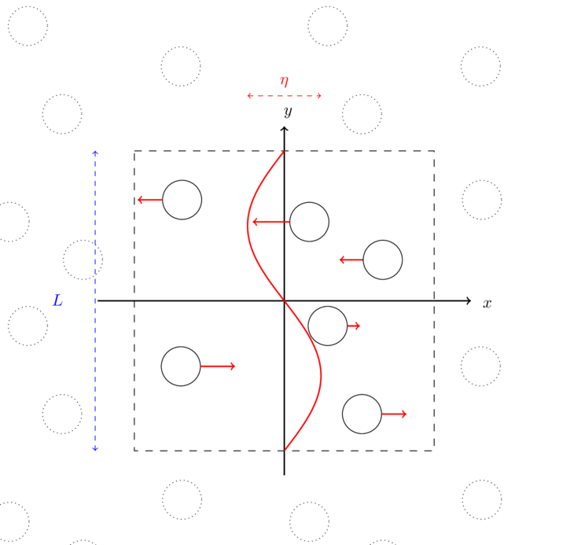

A liquid with a shear forcing profile

[^4]: R. Joubaud and G. Stoltz, **Nonequilibrium Shear Viscosity Computations with Langevin Dynamics**, *Multiscale Modeling & Simulation* 10, no. 1 (2012): 191–216.

## Molecular dynamics with [`Molly.jl`](https://github.com/JuliaMolSim/Molly.jl)

- **MD in pure Julia**, part of [JuliaMolSim](https://juliamolsim.github.io/). Main developer: [Joe Greener](http://jgreener64.github.io/) (Laboratory of Molecular Biology, Cambridge UK)
- Main focus is **differentiable simulation** to parametrize **biomolecular force fields**<sup>1</sup>
- **Growing feature list** (standard interaction terms, particle mesh Ewald, standard integrators, thermostats and barostats, constraints via SHAKE/RATTLE, neighbour lists, some enhanced sampling and free-energy estimators)
- **Compatibility** with atomistic simulation ecosystem (`AtomsBase.jl` and `AtomsCalculators.jl` interfaces, units with `Unitful.jl`, parsing/writing with `Chemfiles.jl`, OpenMM force fields, ASE, GPU acceleration with `KernelAbstractions.jl`)
- **Extensible**: simple use of **custom interaction terms, loggers and simulators**

[video not shown]

Five picoseconds trajectory of the protein Foldit1 (PDB ID 6MRR), simulated with [`Molly.jl`](https://github.com/JuliaMolSim/Molly.jl), rendered with [PyMol](https://pymol.org/).

[^5]: J. G. Greener, **Differentiable Simulation to Develop Molecular Dynamics Force Fields for Disordered Proteins**, *Chemical Science* 15, no. 13 (2024): 4897–4909.

## Shear viscosity of liquid argon with `Molly.jl`

**System setup**

```julia
using Molly, Unitful
import Molly.AtomsCalculators

const force_unit, energy_unit = u"pN", u"pN*Å" # define your physical conditions
const N, T, ρ = 216, 85u"K", 1.41u"g/cm^3" # number of atoms, temperature, density
const m = 39.95u"u" # mass of an argon atom
const ϵ = uconvert(energy_unit, 0.0103u"eV") # Lennard-Jones energy
const σ, rc = 3.405u"Å", 2σ     # interaction and cutoff length
const L = uconvert(u"Å", cbrt(N * m / ρ)) # box length
const γ = m / uconvert(u"ps", σ * sqrt(m / ϵ)) # friction (for Langevin)
const dt, β = 2.0u"fs", inv(Unitful.k * T)

boundary = CubicBoundary(L, L, L) # system setup
coords = place_atoms_on_cubic_lattice(6, 6, 6, boundary)
velocities = [random_velocity(m, T) for i in 1:N]
atoms = [Atom(index=i, ϵ=ϵ, σ=σ, mass=m) for i in 1:N]
lj = LennardJones(cutoff=ShiftedForceCutoff(rc), use_neighbors=true) # Lennard-Jones pairwise potential
nf = CellListMapNeighborFinder(eligible=trues(N, N), n_steps=1,
                               unit_cell=boundary, dist_cutoff=rc) # setup neighbor list
integrator = LangevinSplitting(dt=dt, temperature=T, friction=γ,
                               remove_CM_motion=0, splitting="ABOBA") # underdamped Langevin integrator

sys = System(atoms=atoms, coords=coords, velocities=velocities, boundary=boundary,
             pairwise_inters=(lj,), neighbor_finder=nf,
             force_units=force_unit, energy_units=energy_unit)

function fourier_flux(s::System, args...; kwargs...) # define the flux observable
    return sum(s.velocities[i][1] * exp(2im * π * s.coords[i][2] / L)
               for i in 1:N) / N
end
const TR = typeof(fourier_flux(sys))
```

Run with `simulate!(sys,integrator,n_steps)`

**NEMD**

Only requires defining a custom interaction (a type, and a method for `AtomsCalculators.forces`)

```julia
struct ShearForcing{F,T} # interaction type
    force_profile::F
    η::T
end

function AtomsCalculators.forces(s::System,
        inter::ShearForcing, args...; kwargs...) # force computation
    f = ustrip_vec.(similar(s.coords)) * s.force_units
    @inbounds for i in eachindex(f)
        fx = inter.η * inter.force_profile(s.coords[i][2]) # force in x according to y-position
        f[i] = SVector(fx, zero(fx), zero(fx))
    end
    return f
end

profile(y) = sin(2π * y / L) * force_unit # sinusoidal force profile
forcing = ShearForcing(profile, 5.0)

sys_nemd = System(sys; general_inters=(forcing,),
    loggers=(R=GeneralObservableLogger(fourier_flux, TR, 1),)) # log the flux
```

**Green–Kubo**

Only requires adding a `TimeCorrelationLogger`

```julia
function shear_conjugate_flux(s::System, args...; kwargs...) # define the conjugate flux S_F
    return β * sum(s.velocities[i][1] * sin(2π * s.coords[i][2] / L)
                   for i in 1:N) * s.force_units
end
const TS = typeof(shear_conjugate_flux(sys))
n_corr = 7500 # correlation window

gk = TimeCorrelationLogger(shear_conjugate_flux, fourier_flux,
                           TS, TR, 1, n_corr)

sys_gk = System(sys; loggers=(gk=gk,)) # log the autocorrelation
```

## Liquid argon: results

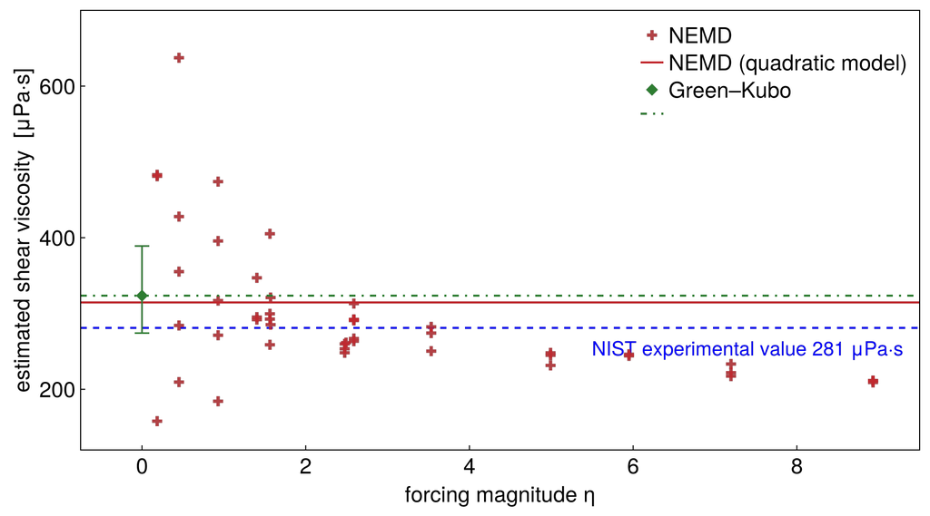

- Every NEMD estimate is **one $100\,\mathrm{ps}$ trajectory**
- Green–Kubo estimate combines **fifty $450\,\mathrm{ps}$ trajectories** ($\approx 4.89 \times$ NEMD budget)
- Both within $15\%$ of the **NIST reference** despite crude interaction model (Lennard-Jones) and small system size ($N=216$)
- Run on a **cluster of laptops** at a CECAM summer school<sup>1</sup>
- **Variance reduction** is an important objective
[^6]: N. Blassel, **Notebook from the CECAM Summer School** (https://github.com/shiva-darshan/CECAMSummerSchool2025/blob/main/notebooks/shear_viscosity_correction.ipynb, 2025).

## Fixing the flux

- Macroscopically, forcing and flux are co-determined by a **constitutive equation** $\overline{R} = \alpha_{F,R}\,\overline{F}$
- NEMD fixes $\overline{F}$ and measures $\overline{R}$ (a conductance); the **dual approach fixes $\overline{R}$ and measures the average forcing needed to sustain it** (a resistance)
- Stochastic generalization<sup>1</sup> of the **Norton method** of Evans and Morriss<sup>2</sup>

[figure not shown]

Liquid argon system, $N=1000$, at equivalent state points $(\eta,r)=(5.0,0.2)$

[^7]: N. Blassel and G. Stoltz, **Fixing the Flux: A Dual Approach to Computing Transport Coefficients**, *Journal of Statistical Physics* 191, no. 2 (2024): 17.
[^8]: D. J. Evans and G. P. Morriss, **Statistical Mechanics of Nonequilibrium Liquids**, *Cambridge University Press*, 2007.

## Constant-flux NEMD

**Constrained dynamics**

Recall the NEMD dynamics
$$\mathrm{d}X_t^\eta =\color{blue}{ b(X_t^\eta)\,\mathrm{d}t + \sigma(X_t^\eta)\,\mathrm{d}W_t} + \color{red}{\eta F(X_t^\eta)\,\mathrm{d}t}$$

Replace the constant forcing magnitude $\eta$ by a **stochastic forcing process**
$$\mathrm{d}Y_t^r =\color{blue}{ b(Y_t^r)\,\mathrm{d}t + \sigma(Y_t^r)\,\mathrm{d}W_t} +\,\color{green}{ F(Y_t^r)\mathrm{d}\Lambda_t^r}$$

chosen so that the flux is **fixed exactly**
$$R(Y_t^r) = r,\qquad \forall\, t\geqslant 0$$

This determines $\Lambda^r$ as
$$\Lambda_t^r = \int_0^t \lambda(Y_s^r)\,\mathrm{d}s + \int_0^t \widetilde\lambda(Y_s^r)\,\mathrm{d}W_s$$
for **explicit observables** $\lambda:\mathcal{X}\to\mathbb{R}$ and $\widetilde\lambda:\mathcal{X}\to \mathbb{R}^{1\times d}$

**Reciprocal estimator of the linear response**

$$\alpha_{F,R} = \lim_{\eta\to 0}\frac{\langle R\rangle_\eta}{\eta}
\qquad
\alpha^*_{F,R} = \lim_{r\to 0}\frac{r}{\langle \lambda\rangle_r}$$

Measure a **resistance** by averaging $\lambda$ along the constrained trajectory

**Dual pair of nonequilibrium ensembles wrt flux/forcing**

**Fixed exactly vs fixed on average** by the steady state (like the microcanonical and canonical duality for energy/temperature)

Averaging $\lambda$ discards the martingale component $\widetilde\lambda$ **variance reduction with a control variate**

- A family of integrators (constant-flux underdamped Langevin with ABO-splitting schemes) fits in about **~110 lines of Julia**, as a **custom simulator** for `Molly` (a type, and a method for `Molly.simulate!`)

## Equivalence of nonequilibrium ensembles

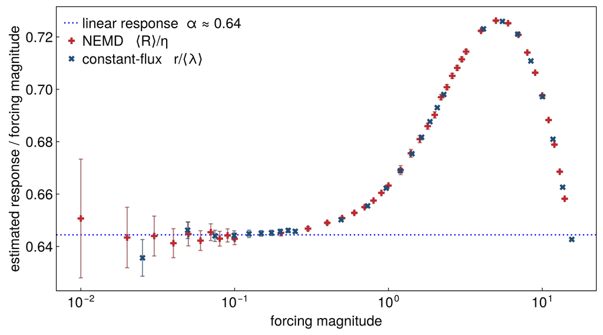

- Compare **finite-difference/ergodic estimators** of the linear responses ($N=1000$)
- Agreement in the **linear regime**, and **well beyond**
- We do not expect $\alpha_{F,R} = \alpha^*_{F,R}$ in general, but **consistency in the thermodynamic limit** $N\to\infty$ (counterexamples exist)

## Anomalous scaling of the variance

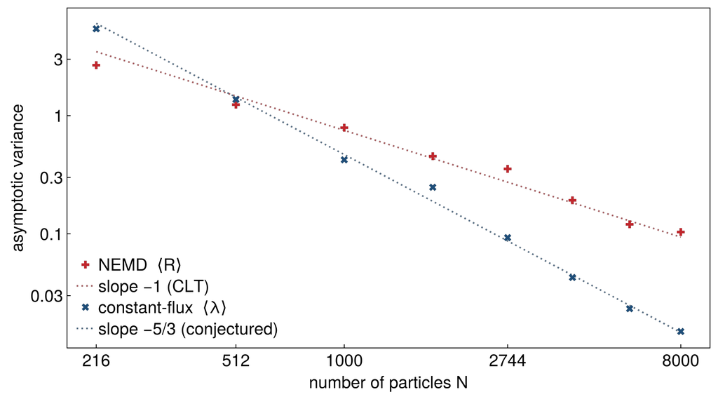

- The **asymptotic variance** $\sigma^2(f)\approx\mathrm{Var}(f)\tau_{\mathrm{corr}}(f)$ is the prefactor in the CLT for ergodic averages
- Expected scaling in $N$ is $\sigma^2(f)\asymp N^{-1}$ by a **spatial CLT**
- Constant-flux asymptotic variance shows **anomalous scaling**, due to $\mathrm{Var}(\lambda)\asymp N^{-5/3}$ (also observe $\tau_{\mathrm{corr}}(\lambda) \ll \tau_{\mathrm{corr}}(R)$)
- Similar results for the constant-flux method in **nonequilibrium DPD**<sup>1</sup>
[^9]: Xinyi Wu and Xiaocheng Shang, **Stochastic Norton Dynamics: An Alternative Approach for the Computation of Transport Coefficients in Dissipative Particle Dynamics**, *Journal of Computational Physics*, 2025, 114316.

## Conclusion

- Transport coefficients are a **computational and mathematical challenge**
- **Innovative variance reduction methods** are needed, and have to be tested **beyond toy examples** (realistic systems, realistic simulation budgets)
- [`Molly.jl`](https://github.com/JuliaMolSim/Molly.jl) helps **bridge the gap** between promising mathematical ideas and promising algorithms
- Most of the theory for the **constant-flux method is still open** (some work currently under way<sup>1</sup>)

**Thank you !**

[^10]: S. Darshan and G. Stoltz, **Equivalence of Norton and Thévenin Ensembles for Mean-Field Interacting Particle Systems**, *In Preparation*, 2026.

## References

Blassel, N. **Molly.jl Implementation of the Constant-Flux Method**. https://github.com/noeblassel/NortonMethod, 2024.

Blassel, N. **Notebook from the CECAM Summer School**. https://github.com/shiva-darshan/CECAMSummerSchool2025/blob/main/notebooks/shear_viscosity_correction.ipynb, 2025.

Blassel, N., Carillo, L., Darshan, S., Gastaldello, R., Iacobucci, A., Marini, E., Santet, R., Shang, X., Stoltz, G., and Vaes, U. **Mathematical Analysis and Numerical Methods for the Computation of Transport Coefficients in Molecular Dynamics**. *Preprint arXiv:2605.10507*, 2026.

Blassel, N., and Stoltz, G. **Fixing the Flux: A Dual Approach to Computing Transport Coefficients**. *Journal of Statistical Physics* 191, no. 2 (2024): 17.

Ciccotti, G., and Jacucci, G. **Direct Computation of Dynamical Response by Molecular Dynamics: The Mobility of a Charged Lennard-Jones Particle**. *Physical Review Letters* 35, no. 12 (1975): 789.

Darshan, S., and Stoltz, G. **Equivalence of Norton and Thévenin Ensembles for Mean-Field Interacting Particle Systems**. *In Preparation*, 2026.

Evans, D. J., and Morriss, G. P. **Statistical Mechanics of Nonequilibrium Liquids**. *Cambridge University Press*, 2007.

Greener, J. G. **Differentiable Simulation to Develop Molecular Dynamics Force Fields for Disordered Proteins**. *Chemical Science* 15, no. 13 (2024): 4897–4909.

Joubaud, R., and Stoltz, G. **Nonequilibrium Shear Viscosity Computations with Langevin Dynamics**. *Multiscale Modeling & Simulation* 10, no. 1 (2012): 191–216.

Kubo, R. **Statistical-Mechanical Theory of Irreversible Processes. I. General Theory and Simple Applications to Magnetic and Conduction Problems**. *Journal of the Physical Society of Japan* 12, no. 6 (1957): 570–86.

Morriss, G. P., and Evans, D. J. **Application of Transient Correlation Functions to Shear Flow Far from Equilibrium**. *Physical Review A* 35, no. 2 (1987): 792.

Spacek, R., Monmarché, P., and Stoltz, G. **Transient Substraction: A Control Variate Method for Computing Transport Coefficients**. *Journal of Statistical Physics* 192, no. 4 (2025): 53.

Wu, Xinyi, and Shang, Xiaocheng. **Stochastic Norton Dynamics: An Alternative Approach for the Computation of Transport Coefficients in Dissipative Particle Dynamics**. *Journal of Computational Physics*, 2025, 114316.